# Point patterns analysis of IBA1 and CD68 cells for WT/Dox and DKK1/On animals after ischemia

Data analysis notebook

Author

Affiliation

Daniel Manrique-Castano, PhD

Univerisity Laval

Published

Monday, August 12, 2024

Keywords

DKK1, MCAO, Brain injury, Bayesian modeling

## 0.1 1. Install and load required packages

The first step is to install the required libraries and load them. To perform a first installation, please uncomment (erase #) in ‘install.packages’ line in the following code chunk. For subsequent code execution, place again # at the beginning of the line to avoid repeated installation.

### 0.1.1 1.1 Install required Packages

```r
# To install packcages uncomment the following line

#install.packages(c("ggplot2","dpylr", "ggridges", "raincloudplots", "cowplot", "data.table", "ggrepel", "sjPlot", "bayesplot", "reshape2", "purrr", "tidyr", "brms", "emmeans", "modelr", "plyr", "pacthwork", "spatstat", "ggdist", "ggpubr", "bayesplot", "RandomFieldsUtils", "RandomFields"))

#library(devtools)
#install_github ("cran/RandomFields")
```

### 0.1.2 1.2 Load required Packages

After installation is done, the libraries should be loaded every time a new R-session is started. We also load `R_rainclouds` and `summarySE.R` functions available on the Github website.

```r
library(ggplot2)
library(ggridges)
library(dplyr)
library(sjPlot)
library(ggrepel)
library(reshape2)
library(purrr)
library(tidyr)
library(brms)
library(emmeans)
library(modelr)
library(tidybayes)
library(plyr)
library(patchwork)
library(spatstat)
library(data.table)
library(cowplot)
library(ggdist)
library(ggpubr)
library(bayesplot)
library(RandomFieldsUtils)
library(RandomFields)
```

## 0.2 2. Load the experimental data

We load the tables generated in the **batch processing script**. This include 1) The **QuPath-generated annotations file** summarizing cell detections in different brain regions as specified in the section of materials and methods in the main article. 2) .csv tables with **cell intensities** and **Tessellation-based cell allocation**. 3) Tables containing **nearest neighbors distance (nnd)** calculations and 4) Tables with **nnd centroids**.

### 0.2.1 2.1 Load Point patterns

We also load **Hyperframes R-objects** containing point patterns and density kernels. The `Point_Patterns_5x` object contains cell in the whole ischemic hemisphere (as shown in supplementary figure 1) and `Point_Patterns_10x` groups detected cells in the lesion site at the level of bregma.

```r
# 3) Load hyperframes with point patterns
PointPatterns <- readRDS("PointPatterns/PointPatterns.rds")
PointPatterns$Condition <- factor(PointPatterns$Condition, levels = c("WT", "DKK1"))

PointPatterns_Dkk1 <- subset(PointPatterns, Condition=="DKK1", select = 1:5)
PointPatterns_WT <- subset(PointPatterns, Condition=="WT", select = 1:5)
```

## 0.3 3. Relative distribution (x-axis) of immune / inflammatory cells

### 0.3.1 3.1 Calculate the relative distribution

```r
# For CD68High
CD68High_Rhohat_WT <- with(PointPatterns_WT, spatstat.explore::rhohat.ppp(CD68High, "x", do.CI = FALSE))

CD68High_PoolRhohat_WT  <- spatstat.explore::pool.fv(CD68High_Rhohat_WT$`12`, CD68High_Rhohat_WT$`13`, CD68High_Rhohat_WT$`14`, CD68High_Rhohat_WT$`15`, CD68High_Rhohat_WT$`16`, CD68High_Rhohat_WT$`17`, CD68High_Rhohat_WT$`18`)

CD68High_Rhohat_DKK1 <- with(PointPatterns_Dkk1, spatstat.explore::rhohat.ppp(CD68High, "x", do.CI = FALSE))

CD68High_PoolRhohat_DKK1  <- spatstat.explore::pool.fv(CD68High_Rhohat_DKK1$`1`, CD68High_Rhohat_DKK1$`11`, CD68High_Rhohat_DKK1$`19`, CD68High_Rhohat_DKK1$`110`,CD68High_Rhohat_DKK1$`111`, CD68High_Rhohat_DKK1$`112`, CD68High_Rhohat_DKK1$`113`, CD68High_Rhohat_DKK1$`114`, CD68High_Rhohat_DKK1$`115`, CD68High_Rhohat_DKK1$`116`)


# For Iba1
Iba1_Rhohat_WT <- with(PointPatterns_WT, spatstat.explore::rhohat.ppp(Iba1, "x", do.CI = FALSE))

Iba1_PoolRhohat_WT  <- spatstat.explore::pool.fv(Iba1_Rhohat_WT$`12`, Iba1_Rhohat_WT$`13`, Iba1_Rhohat_WT$`14`, Iba1_Rhohat_WT$`15`, Iba1_Rhohat_WT$`16`, Iba1_Rhohat_WT$`17`, Iba1_Rhohat_WT$`18`)

Iba1_Rhohat_DKK1 <- with(PointPatterns_Dkk1, spatstat.explore::rhohat.ppp(Iba1, "x", do.CI = FALSE))

Iba1_PoolRhohat_DKK1  <- spatstat.explore::pool.fv(Iba1_Rhohat_DKK1$`1`, Iba1_Rhohat_DKK1$`11`, Iba1_Rhohat_DKK1$`19`, Iba1_Rhohat_DKK1$`110`,Iba1_Rhohat_DKK1$`111`, Iba1_Rhohat_DKK1$`112`, Iba1_Rhohat_DKK1$`113`, Iba1_Rhohat_DKK1$`114`, Iba1_Rhohat_DKK1$`115`, Iba1_Rhohat_DKK1$`116`)
```

### 0.3.2 3.2 Plot the rhohat

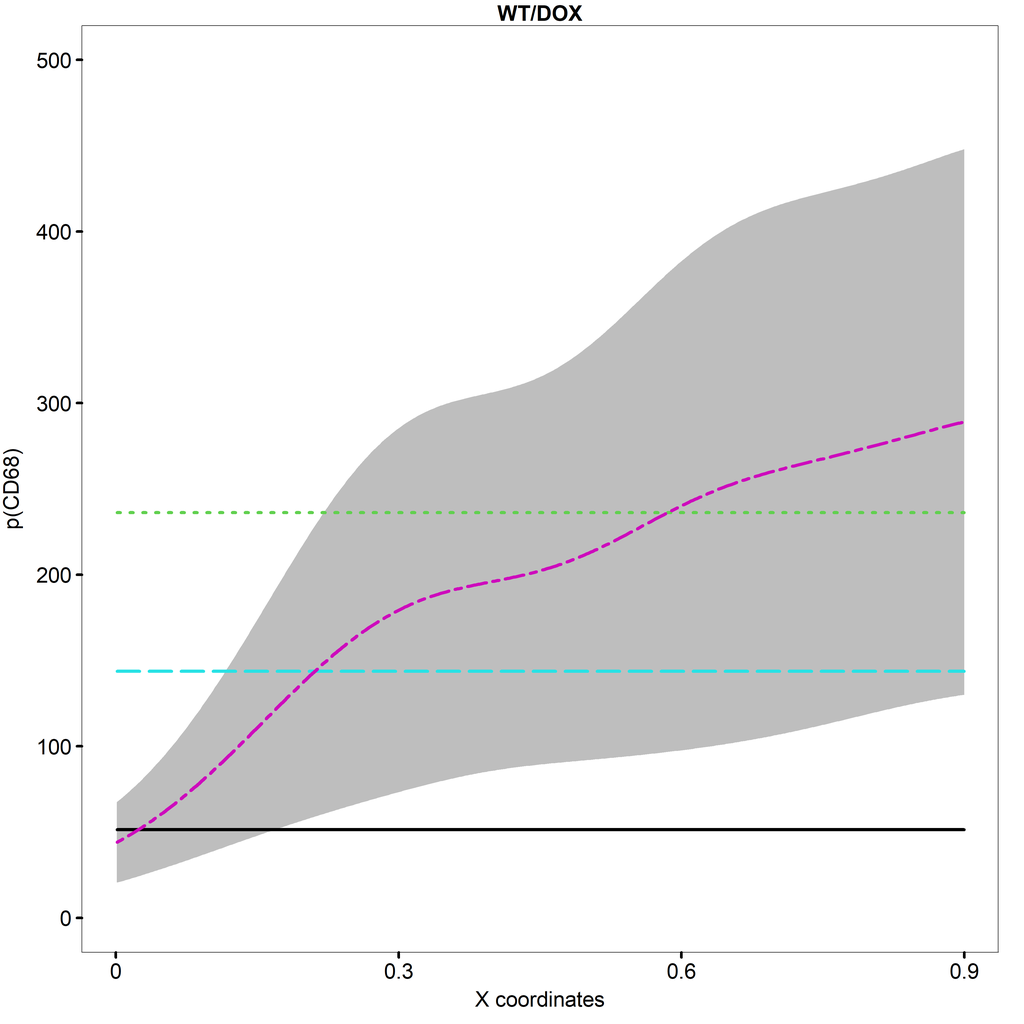

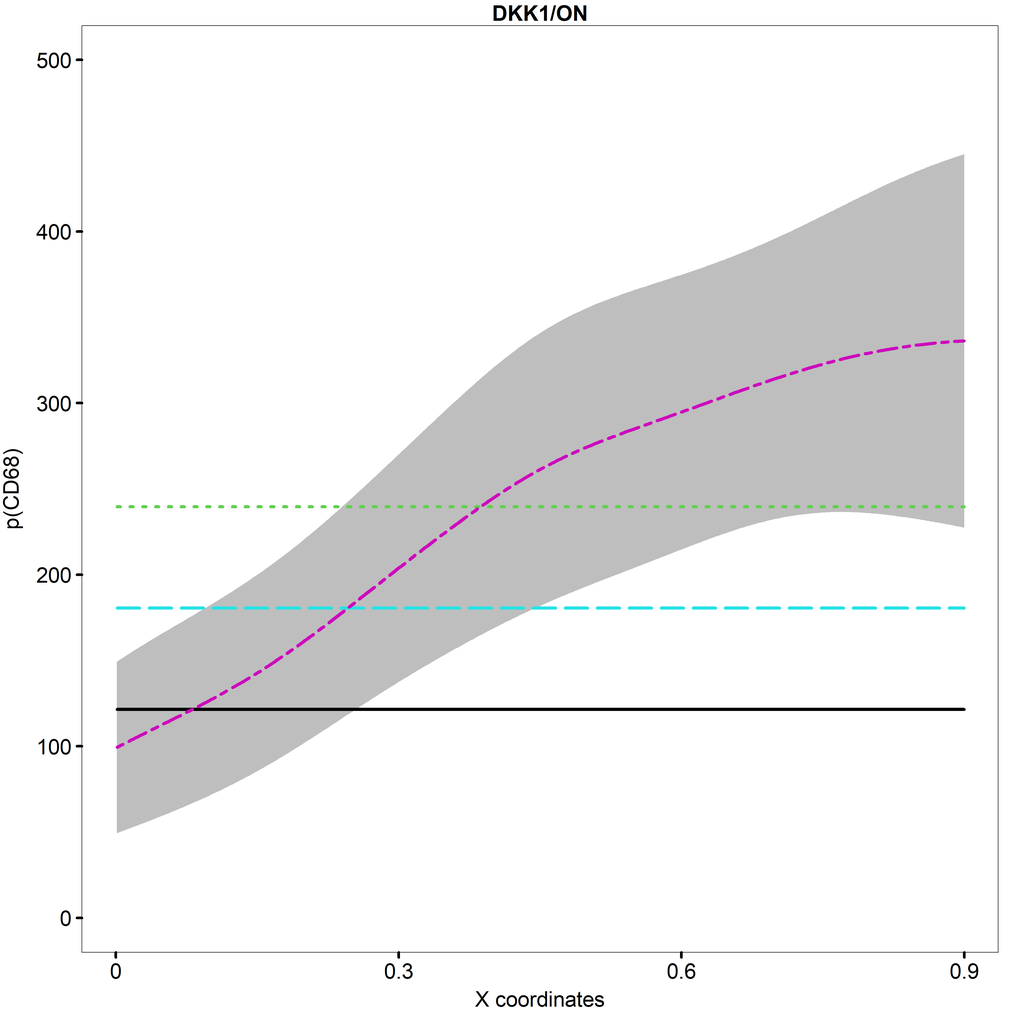

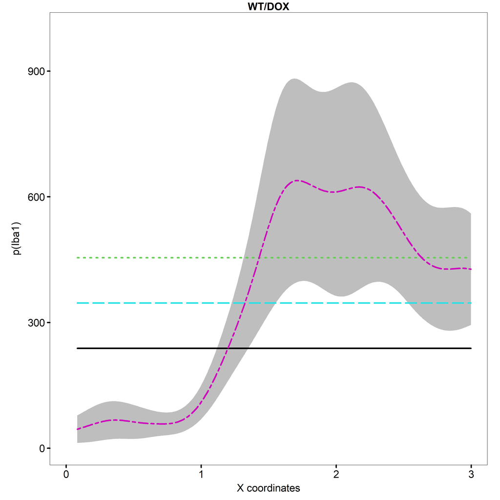

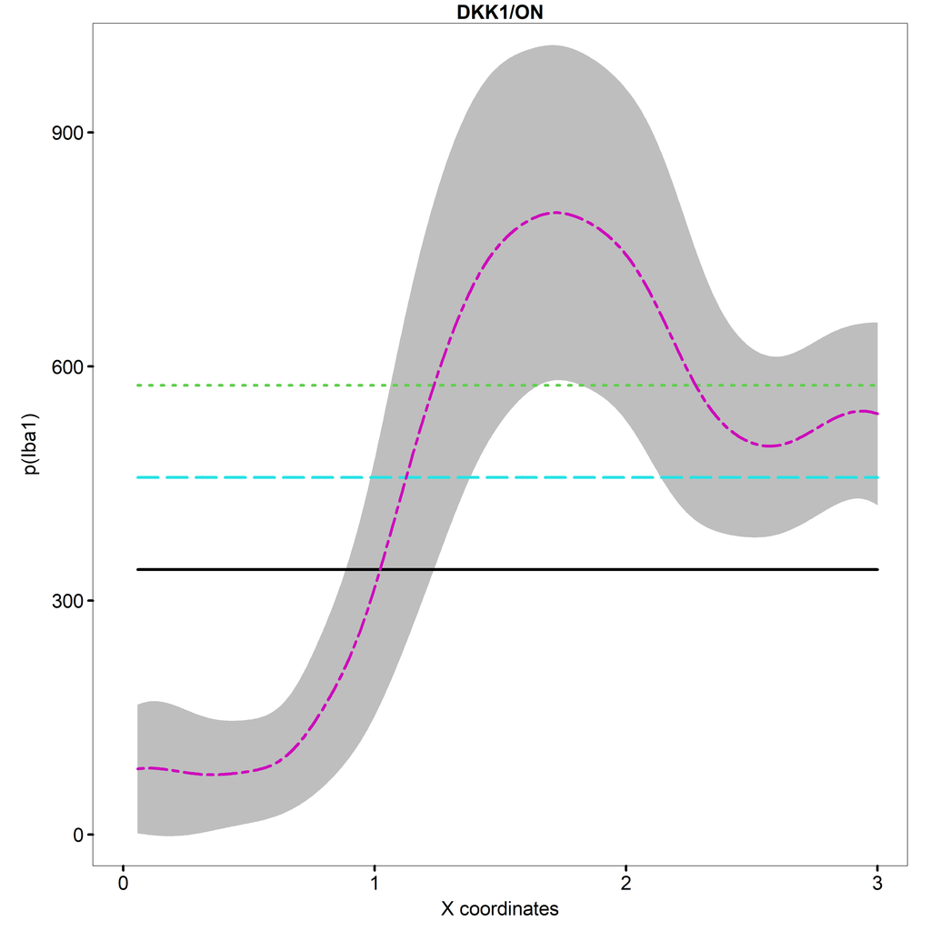

```r
#png("Plots/CD68High_PoolRhohat_WT.png", width = 500, height = 400)
par(mar=c(5,6,0.5,0.5)+2)
plot(CD68High_PoolRhohat_WT,
     shade = c("lorho", "hirho"),
     las=1,
     legendargs=list(xpd=TRUE),
     main = "WT/DOX",
     ylim =c(0, 500),
     xlim =c(1.8, 2.7),
     xlab = "",
     ylab = "",
     cex.main = 2.5,
     cex.lab = 2.5,
     cex.axis = 2.5,
     lwd = 6,
     legend=FALSE,
     xaxt = "n",
     yaxt = "n")

axis(1, at = seq(1.8, 3, 0.3), labels = c("0", "0.3", "0.6", "0.9", "0.12"), cex.axis=2.5, padj = 0.5, lwd.ticks = 5)

axis(2, at = seq(0, 500, 100), labels = c("0","100", "200", "300", "400", "500"), cex.axis=2.5, padj = 0.5, lwd.ticks = 5, las = 2)

title(xlab = "X coordinates", mgp = c(4.5, 1, 0), cex.lab = 2.5)
title(ylab = "p(CD68)", mgp = c(6, 1, 0), cex.lab = 2.5)
#dev.off()

#png("Plots/CD68High_PoolRhohat_DKK1.png", width = 500, height = 400)
par(mar=c(5,6,0.5,0.5)+2)
plot(CD68High_PoolRhohat_DKK1,
     shade = c("lorho", "hirho"),
     las=1,
     legendargs=list(xpd=TRUE),
     main = "DKK1/ON",
     ylim =c(0, 500),
     xlim =c(1.8, 2.7),
     xlab = "",
     ylab = "",
     cex.main = 2.5,
     cex.lab = 2.5,
     cex.axis = 2.5,
     lwd = 6,
     legend=FALSE,
     xaxt = "n",
     yaxt = "n")

axis(1, at = seq(1.8, 3, 0.3), labels = c("0", "0.3", "0.6", "0.9", "0.12"), cex.axis=2.5, padj = 0.5, lwd.ticks = 5)

axis(2, at = seq(0, 500, 100), labels = c("0","100", "200", "300", "400", "500"), cex.axis=2.5, padj = 0.5, lwd.ticks = 5, las = 2)

title(xlab = "X coordinates", mgp = c(4.5, 1, 0), cex.lab = 2.5)
title(ylab = "p(CD68)", mgp = c(6, 1, 0), cex.lab = 2.5)
#dev.off()

par(mar=c(5,8,0.5,0.5)+2)
plot(Iba1_PoolRhohat_WT,
     shade = c("lorho", "hirho"),
     las=1,
     legendargs=list(xpd=TRUE),
     main = "WT/DOX",
     ylim =c(0, 1000),
     xlim =c(0, 3),
     xlab = "",
     ylab = "",
     cex.main = 2.5,
     cex.lab = 2.5,
     cex.axis = 2.5,
     lwd = 6,
     legend=FALSE,
     xaxt = "n",
     yaxt = "n")

axis(1, at = seq(0, 3, 1), labels = c("0", "1", "2", "3"), cex.axis=2.5, padj = 0.5, lwd.ticks = 5)

axis(2, at = seq(0, 1000, 300), labels = c("0","300", "600", "900"), cex.axis=2.5, padj = 0.5, lwd.ticks = 5, las = 2)

title(xlab = "X coordinates", mgp = c(4.5, 1, 0), cex.lab = 2.5)
title(ylab = "p(Iba1)", mgp = c(6, 1, 0), cex.lab = 2.5)
par(mar=c(5,8,0.5,0.5)+2)
plot(Iba1_PoolRhohat_DKK1,
     shade = c("lorho", "hirho"),
     las=1,
     legendargs=list(xpd=TRUE),
     main = "DKK1/ON",
     ylim =c(0, 1000),
     xlim =c(0, 3),
     xlab = "",
     ylab = "",
     cex.main = 2.5,
     cex.lab = 2.5,
     cex.axis = 2.5,
     lwd = 6,
     legend=FALSE,
     xaxt = "n",
     yaxt = "n")

axis(1, at = seq(0, 3, 1), labels = c("0", "1", "2", "3"), cex.axis=2.5, padj = 0.5, lwd.ticks = 5)

axis(2, at = seq(0, 1000, 300), labels = c("0","300", "600", "900"), cex.axis=2.5, padj = 0.5, lwd.ticks = 5, las = 2)

title(xlab = "X coordinates", mgp = c(4.5, 1, 0), cex.lab = 2.5)
title(ylab = "p(Iba1)", mgp = c(6, 1, 0), cex.lab = 2.5)
```

# 1 We plot the numeric values

```r
print(paste("The mean spatial intensity for CD68 in WT is:", mean(CD68High_PoolRhohat_WT$poolave)))
```

```
[1] "The mean spatial intensity for CD68 in WT is: 143.760561365859"
```

```r
print(paste("The higher 95% CI for CD68 in WT is:", mean(CD68High_PoolRhohat_WT$hiave)))
```

```
[1] "The higher 95% CI for CD68 in WT is: 236.124977086118"
```

```r
print(paste("The lower 95% CI for CD68 in WT is:", mean(CD68High_PoolRhohat_WT$loave)))
```

```
[1] "The lower 95% CI for CD68 in WT is: 51.3961456455995"
```

```r
print(paste("The mean spatial intensity for CD68 in DKK1 is:", mean(CD68High_PoolRhohat_DKK1$poolave)))
```

```
[1] "The mean spatial intensity for CD68 in DKK1 is: 180.539556976216"
```

```r
print(paste("The higher 95% CI for CD68 in DKK1 is:", mean(CD68High_PoolRhohat_DKK1$hiave)))
```

```
[1] "The higher 95% CI for CD68 in DKK1 is: 239.53990006722"
```

```r
print(paste("The lower 95% CI for CD68 in DKK1 is:", mean(CD68High_PoolRhohat_DKK1$loave)))
```

```
[1] "The lower 95% CI for CD68 in DKK1 is: 121.539213885211"
```

```r
print(paste("The mean spatial intensity for IBA1 in WT is:", mean(Iba1_PoolRhohat_WT$poolave)))
```

```
[1] "The mean spatial intensity for IBA1 in WT is: 346.48560989752"
```

```r
print(paste("The higher 95% CI for IBA1 in WT is:", mean(Iba1_PoolRhohat_WT$hiave)))
```

```
[1] "The higher 95% CI for IBA1 in WT is: 454.685988074684"
```

```r
print(paste("The lower 95% CI for IBA1 in WT is:", mean(Iba1_PoolRhohat_WT$loave)))
```

```
[1] "The lower 95% CI for IBA1 in WT is: 238.285231720356"
```

```r
print(paste("The mean spatial intensity for IBA1 in DKK1 is:", mean(Iba1_PoolRhohat_DKK1$poolave)))
```

```
[1] "The mean spatial intensity for IBA1 in DKK1 is: 457.854772114537"
```

```r
print(paste("The higher 95% CI for IBA1 in WT in DKK1 is:", mean(Iba1_PoolRhohat_DKK1$hiave)))
```

```
[1] "The higher 95% CI for IBA1 in WT in DKK1 is: 575.97047910128"
```

```r
print(paste("The lower 95% CI for IBA1 in WT in DKK1 is:", mean(Iba1_PoolRhohat_DKK1$loave)))
```

```
[1] "The lower 95% CI for IBA1 in WT in DKK1 is: 339.739065127793"
```

## 1.1 Fit a model

```r
CD68_fit1 <- mppm(CD68High ~ Condition, PointPatterns)
CD68_fit1_CI <- confint(CD68_fit1)

CD68_fit1
```

```
Point process model fitted to 17 point patterns
Call: mppm(CD68High ~ Condition, PointPatterns)
Log trend formula: ~Condition

Fitted trend coefficients:
  (Intercept) ConditionDKK1
    5.0274907     0.1795013

Interaction for all patterns:   Poisson process
```

```r
CD68_fit1_CI
```

```
                  2.5 %    97.5 %
(Intercept)   5.0093468 5.0456346
ConditionDKK1 0.1573372 0.2016654
```

```r
Iba1_fit1 <- mppm(Iba1 ~ Condition, PointPatterns)
Iba1_fit1_CI <- confint(Iba1_fit1)

Iba1_fit1
```

```
Point process model fitted to 17 point patterns
Call: mppm(Iba1 ~ Condition, PointPatterns)
Log trend formula: ~Condition

Fitted trend coefficients:
  (Intercept) ConditionDKK1
    5.8606816     0.2752704

Interaction for all patterns:   Poisson process
```

```r
Iba1_fit1_CI
```

```
                  2.5 %    97.5 %
(Intercept)   5.8509303 5.8704329
ConditionDKK1 0.2630818 0.2874591
```